# 5.1 Discrete Random Variables

## Goals

1. Discuss discrete random variables using key terminology.
2. Calculate the expected value and standard deviation of a discrete random variable.

## Discrete Random Variables

A **random variable** is a quantitative variable whose values are based on chance. By “chance”, we mean that you can’t *know* the outcome before it occurs.

A **discrete random variable** is a random variable whose possible values can be listed.

## Notation

- Variables: \(x\),\(y\),\(z\)
- Random variables: \(X\), \(Y\), \(Z\)
- The event that the random variable \(X\) equals \(x\): \(\{X=x\}\)
- The probability that the random variable \(X\) equals \(x\): \(P(X=x)\)

## Probability Histograms

A **probability histogram** is a histogram where the heights of the bars correspond to the probability of each value.

- For discrete random variables, each “bin” is one of the listed values.

## Example: Probability Histograms

| Number of Siblings, \(x\) | 0 | 1 | 2 | 3 | 4 |
| --- | --- | --- | --- | --- | --- |
| **Probability**, \(P(X=x)\) | 0.200 | 0.425 | 0.275 | 0.075 | 0.025 |

(Assume for the sake of the example that no one has more than 4 siblings.)

| Number of Siblings, \(x\) | 0 | 1 | 2 | 3 | 4 |
| --- | --- | --- | --- | --- | --- |
| **Probability**, \(P(X=x)\) | 0.200 | 0.425 | 0.275 | 0.075 | 0.025 |

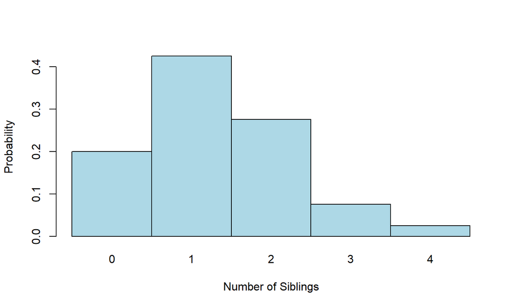

## The Mean of a Discrete Random Variable

The mean of a discrete random variable \(X\) is denoted \(\mu_X\).

\[\mu_X = x_1P(X=x_1) + x_2P(X=x_2) + \dots + x_nP(X=x_n).\]

If it’s clear which random variable we’re talking about, we can just write \(\mu\).

## Example

| Number of Siblings, \(x\) | 0 | 1 | 2 | 3 | 4 |
| --- | --- | --- | --- | --- | --- |
| **Probability**, \(P(X=x)\) | 0.200 | 0.425 | 0.275 | 0.075 | 0.025 |

\[\mu = 0(0.200)+1(0.425)+2(0.275)+3(0.075)+4(0.025)=1.3\]  
*Interpretation*: in a large number of independent observations of a random variable \(X\), the mean of those observations will approximately equal \(\mu\).

## The Mean of a Discrete Random Variable

The mean of a random variable is also called the **expected value** or **expectation**.

Since measures of center are meant to identify the most common or most likely, you can think of this as the value we *expect* to see (most often).

## Law of Large Numbers

The larger the number of observations, the closer their average tends to be to \(\mu\). This is known as the **law of large numbers**.

## Example: Law of Large Numbers

- A random sample of 30 gave me a mean of \(\bar{x}=1.53\).
- A random sample of 100 gave me a mean of \(\bar{x}=1.47\).
- A random sample of 1000 gave me a mean of \(\bar{x}=1.307\).

## Standard Deviation of a Discrete Random Variable

\[ \sigma_X^2 = [x_1^2P(X=x_1) + x_2^2P(X=x_2) + \dots + x_n^2P(X=x_n)]-\mu_X^2\]

As before, the standard deviation is the square root of the variance: \[\sigma = \sqrt{\sigma^2}\]

## Example

In general, a table is the best way to keep track of a variance calculation:

| \(x\) | \(P(X=x)\) | \(xP(X=x)\) | \(x^2\) | \(x^2P(X=x)\) |
| --- | --- | --- | --- | --- |
| 0 | 0.200 | 0 | 0 | 0 |
| 1 | 0.425 | 0.425 | 1 | 0.425 |
| 2 | 0.275 | 0.550 | 4 | 1.100 |
| 3 | 0.075 | 0.225 | 9 | 0.675 |
| 4 | 0.025 | 0.100 | 16 | 0.400 |
|  |  | \(\mu\) = 1.3 |  | Total = 2.6 |

| \(x\) | \(P(X=x)\) | \(xP(X=x)\) | \(x^2\) | \(x^2P(X=x)\) |
| --- | --- | --- | --- | --- |
| 0 | 0.200 | 0 | 0 | 0 |
| 1 | 0.425 | 0.425 | 1 | 0.425 |
| 2 | 0.275 | 0.550 | 4 | 1.100 |
| 3 | 0.075 | 0.225 | 9 | 0.675 |
| 4 | 0.025 | 0.100 | 16 | 0.400 |
|  |  | \(\mu\) = 1.3 |  | Total = 2.6 |

## Homework Problems

Section 5.1 Exercises 1 and 2